# Comparative analysis of CD26 and CT26+CAF

heinin

2026-01-31

## Libraries and environment variables

```r
library(workflowr)
library(Seurat)
library(googlesheets4)
library(tidyverse)
library(plyr)
library(SoupX)
library(scProportionTest)
library(clusterProfiler)
library(org.Hs.eg.db)
library(org.Mm.eg.db)
library(biomaRt)
library(gprofiler2)

setwd("/home/hnatri/PIPAC_spatial/")
set.seed(1234)
options(future.globals.maxSize = 30000 * 1024^2)
reduction <- "umap"

source("/home/hnatri/SingleCellBestPractices/scripts/preprocessing_qc_module.R")
source("/home/hnatri/SingleCellBestPractices/scripts/integration_module.R")
source("/home/hnatri/Utilities/utilities.R")
source("/home/hnatri/PIPAC_spatial/code/PIPAC_colors_themes.R")
source("/home/hnatri/PIPAC_spatial/code/plot_functions.R")

# Markers
main_plot_features <- c("PTPRC", "CD3D", "CD3E", "CD4", "CD8A", "JAK1", "JAK2", "STAT4", "STAT3", "TIGIT", "GZMB", "SELL", "CD19", "CD68", "CD44", "MARCO", "APOE", "C1QB", "C1QBP", "CD163", "SPP1", "VCAN", "MUC5AC", "NOTCH3", "RGS5", "MS4A1", "PGA5", "PLVAP", "CCL21", "LYVE", "SPARCL1", "FN1", "DCN", "LUM", "COL1A2", "PDPN", "ACTA2", "LMNA", "EGR3", "TP53", "JUN", "FOS", "BRAF", "KIT", "SOX9", "RNF43", "EPCAM", "PECAM", "CEACAM", "TGFB1", "JUNB", "TCF7", "GZMA", "GZMK", "CD47", "CD74", "LYZ", "TREM2", "CD247", "COL5A1", "SPARC", "CD36", "CTLA4", "RGS1", "CCL2", "SELENOP", "LYVE1", "CTSD", "MMP9", "CDK1", "FLT1", "RAMP2", "CCL14", "MCAM", "NRP1", "CEACAM6", "IL32", "TGFBI", "VEGFA", "LAMP1", "IGFBP7", "POSTN", "C1S", "C1R", "CSF1", "NOTCH1", "FOXP3", "IL2RB", "TUBA1B", "S100A9", "C3", "CXCR2", "SDC1", "CD38", "IGHG1", "PRDX4", "ICAM1", "GATA2", "CXCL3")

mycafs <- c("TGFB1", "ACTA2", "TAGLN") #"HOPX", "MYL9"
icafs <- c("IL6", "CXCL12", "CXCL14") #"CXCL13",
abcafs <- c("CD74", "HLA-DPB1", "HLA-DPB2", "HLA-DQA1", "HLA-DRA", "HLA-DRB1")
ficafs <- c("SFRP2", "SFRP4", "COMP", "CXCL14", "PLA2G2A", "ASPN")

main_plot_features <- c(main_plot_features, mycafs, icafs, abcafs, ficafs)
main_plot_features <- unique(main_plot_features)

main_plot_features <- gorth(main_plot_features, source_organism = "hsapiens", target_organism = "mmusculus")$ortholog_name
```

## Import data

```r
seurat_data <- readRDS("/tgen_labs/banovich/PIPAC/CAF_scRNAseq/PDX_CAF_Seurat_annotated.rds")

seurat_data$Updated_Annotation <- seurat_data$Annotation

table(seurat_data$Updated_Annotation)
```

```
               CAF1                CAF2                CAF3                CAF4
                142                2059                2564                2131
               CAF5                CAF6                CAF7 Lymphoid1_CD8_TIGIT
               1468                 215                2690                1579
          Lymphoid2         Lymphoid3_B      Lymphoid3_GZMB            Myeloid1
               1478                 619                 921                2029
           Myeloid2            Myeloid3            Myeloid4            Myeloid5
               1711                 194                  80                1616
             Tumor1              Tumor2              Tumor3              Tumor4
               3963                3933                2310                1885
             Tumor5              Tumor6              Tumor7              Tumor8
               2951                 618                 750                4200
             Tumor9
               2955
```

## Comparative analysis

### Cell type proportions

```r
table(seurat_data$Sample)
```

```
    CT26 CT26_CAF
   19641    25420
```

```r
table(seurat_data$Sample, seurat_data$Updated_Annotation)
```

```
           CAF1 CAF2 CAF3 CAF4 CAF5 CAF6 CAF7 Lymphoid1_CD8_TIGIT Lymphoid2
  CT26       93  523  530  685  568  118  774                1075       773
  CT26_CAF   49 1536 2034 1446  900   97 1916                 504       705

           Lymphoid3_B Lymphoid3_GZMB Myeloid1 Myeloid2 Myeloid3 Myeloid4
  CT26             334            710      854     1168      174       58
  CT26_CAF         285            211     1175      543       20       22

           Myeloid5 Tumor1 Tumor2 Tumor3 Tumor4 Tumor5 Tumor6 Tumor7 Tumor8
  CT26         1123   1619   1353    905    669    979    316    214   2393
  CT26_CAF      493   2344   2580   1405   1216   1972    302    536   1807

           Tumor9
  CT26       1633
  CT26_CAF   1322
```

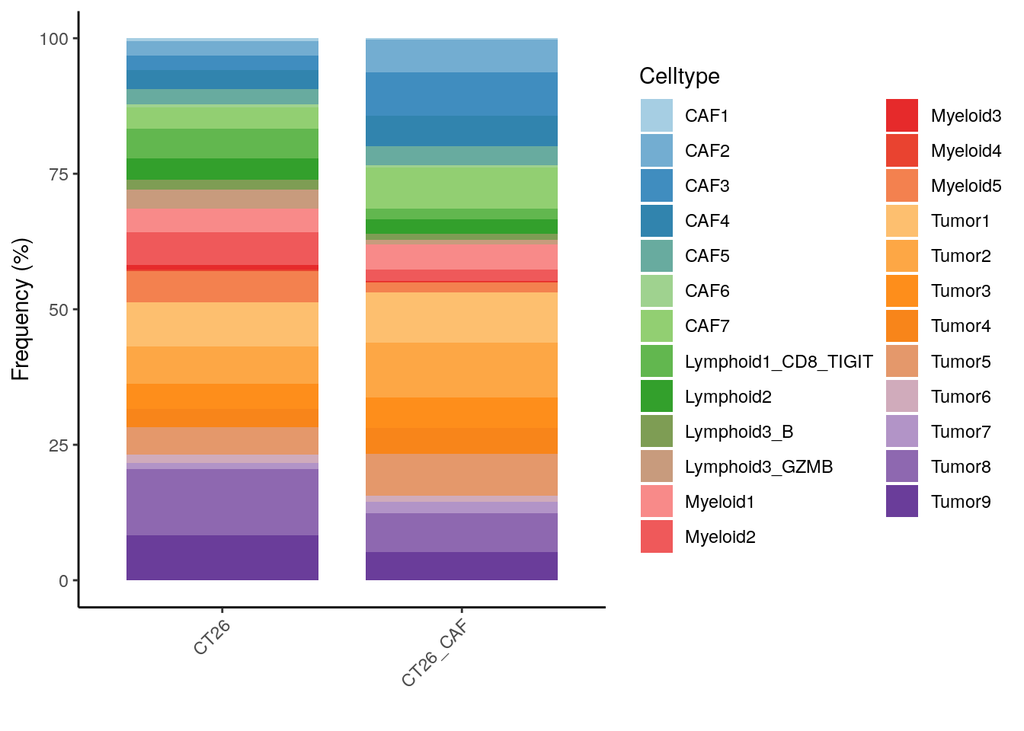

```r
cts <- as.factor(sort(unique(as.character(seurat_data$Updated_Annotation))))
ct_col <- colorRampPalette(brewer.pal(10, "Paired"))(nb.cols <- length(cts))
names(ct_col) <- levels(cts)

create_barplot(seurat_data,
               group_var = "Sample",
               plot_var = "Updated_Annotation",
               plot_levels = sort(unique(as.character(seurat_data$Updated_Annotation))),
               group_levels = sort(unique(seurat_data$Sample)),
               plot_colors = ct_col,
               var_names =  c("Frequency (%)", ""),
               legend_title = "Celltype")
```

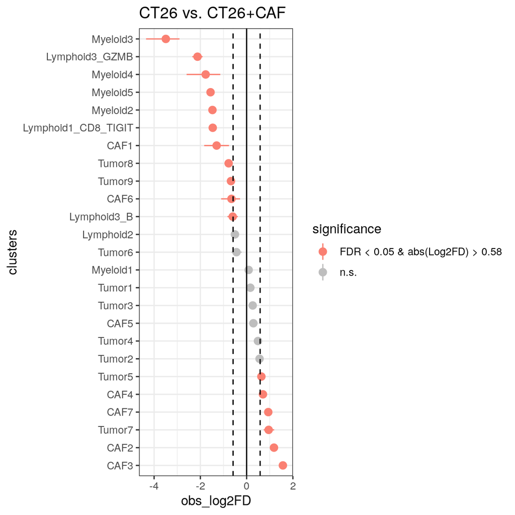

```r
prop_test <- sc_utils(seurat_data)
prop_test <- permutation_test(
    prop_test, cluster_identity = "Updated_Annotation",
    sample_1 = "CT26", sample_2 = "CT26_CAF",
    sample_identity = "Sample")

permutation_plot(prop_test) +
  ggtitle("CT26 vs. CT26+CAF")
```

```r
#filename <- "/home/hnatri/PIPAC_spatial/CT26_CAF_celltypeprops.pdf"
#
#pdf(file=filename,
#    width = 5.5,
#    height = 6)
#
#permutation_plot(prop_test) +
#  ggtitle("CT26 vs. CT26+CAF")
#
#dev.off()
```

## DEGs, CAFs only

```r
#tumor_DEGs <- get_DEGs(seuratdata = seurat_data,
#                       celltypes = unique(seurat_data$harmony_snn_res.0.8),
#                       groupvar = "PrePost",
#                       group1 = "Treated",
#                       group2 = "Baseline")
#tumor_only <- subset(seurat_data, subset = harmony_snn_res.0.8 %in% c(0, 2, 4, 7, 18, 21,
#                                                                            16, 5, 9, 8, 14, 15, 3,
#                                                                            19, 1, 6))

#tumor_only <- c("CAF1", "CAF2", "CAF3", "CAF4", "CAF5", "CAF6", "CAF7",
#                "Proliferating1", "Proliferating2", "Proliferating3",
#                "Tumor1", "Tumor2", "Tumor3", "Tumor4", "Tumor5")

caf_only <- c("CAF1", "CAF2", "CAF3", "CAF4", "CAF5", "CAF6", "CAF7")

caf_only <- subset(seurat_data, subset = Updated_Annotation %in% caf_only)

DefaultAssay(caf_only) <- "RNA"
caf_only <- JoinLayers(caf_only)
caf_only <- NormalizeData(caf_only)

Idents(caf_only) <- caf_only$Sample
caf_DEGs <- FindMarkers(caf_only,
                          ident.1 = "CT26_CAF",
                          ident.2 = "CT26")

# Distribution of p-values and log2FC
hist(caf_DEGs$p_val)
hist(caf_DEGs$p_val_adj)
hist(caf_DEGs$avg_log2FC)

ensembl <- useMart("ensembl", dataset="mmusculus_gene_ensembl")
geneinfo <- getBM(attributes=c("mgi_symbol", "ensembl_gene_id"),
      filters = 'mgi_symbol',
      values = rownames(caf_DEGs),
      mart = ensembl)

caf_DEGs$gene_id <- mapvalues(rownames(caf_DEGs),
                                   from = geneinfo$mgi_symbol,
                                   to = geneinfo$ensembl_gene_id)

caf_DEGs_sig <- caf_DEGs %>%
  filter(p_val_adj < 0.01,
         abs(avg_log2FC) > 1,
         (pct.1 > 0.2 | pct.2 > 0.2))

caf_DEGs_sig %>%
  filter(avg_log2FC>0) %>% rownames() %>% length()

caf_DEGs_sig %>%
  filter(avg_log2FC<0) %>% rownames() %>% length()
```

## Some features upregulated in CT26+CAF

```r
caf_DEGs_sig %>%
  filter(avg_log2FC>0) %>%
  arrange(desc(avg_log2FC)) %>%
  head(20)

upreg <- caf_DEGs_sig %>%
  filter(avg_log2FC>0) %>%
  arrange(desc(avg_log2FC)) %>%
  rownames()

VlnPlot(caf_only,
        group.by = "Sample",
        features = head(upreg, n = 12),
        pt.size = 0,
        ncol = 4) &
  theme_bw() &
  NoLegend() &
  RotatedAxis() &
  xlab("")
```

## Some features downregulated in CT26+CAF

```r
caf_DEGs_sig %>%
  filter(avg_log2FC<0) %>%
  arrange(desc(avg_log2FC)) %>%
  tail(20)

downreg <- caf_DEGs_sig %>%
  filter(avg_log2FC<0) %>%
  arrange(desc(avg_log2FC)) %>%
  rownames()

VlnPlot(caf_only,
        group.by = "Sample",
        features = tail(downreg, n = 12),
        pt.size = 0,
        ncol = 4) &
  theme_bw() &
  NoLegend() &
  RotatedAxis() &
  xlab("")
```

## Pathway enrichment, upregulated in CT26+CAF

```r
caf_DEGs_up <- caf_DEGs_sig %>%
  filter(avg_log2FC>0)

gse_res <- enrichGO(rownames(caf_DEGs_up),
                    ont ="BP",
                    keyType = "SYMBOL",
                    OrgDb = org.Mm.eg.db,
                    minGSSize = 3,
                    maxGSSize = 1000,
                    pvalueCutoff = 0.01,
                    qvalueCutoff = 1,
                    universe = rownames(caf_DEGs),
                    pAdjustMethod = "none")

ddp <- dotplot(gse_res, showCategory=10, font.size=10, color="pvalue") +
  theme(legend.text=element_text(size=5),
        legend.position = "top",
        legend.box = "vertical",
        text = element_text(size=6))

dim(gse_res)

ddp

#filename <- "/home/hnatri/PIPAC_spatial/CT26_CAF_pathways.pdf"
#
#pdf(file=filename,
#    width = 4.5,
#    height = 6)
#
#ddp
#
#dev.off()
```

## Pathway enrichment, downregulated in CT26+CAF

```r
caf_DEGs_down <- caf_DEGs_sig %>%
  filter(avg_log2FC<0)

gse_res <- enrichGO(rownames(caf_DEGs_down),
                    ont ="BP",
                    keyType = "SYMBOL",
                    OrgDb = org.Mm.eg.db,
                    minGSSize = 3,
                    maxGSSize = 1000,
                    pvalueCutoff = 0.01,
                    qvalueCutoff = 1,
                    universe = rownames(caf_DEGs),
                    pAdjustMethod = "none")

ddp <- dotplot(gse_res, showCategory=10, font.size=10, color="pvalue") +
  theme(legend.text=element_text(size=5),
        legend.position = "top",
        legend.box = "vertical",
        text = element_text(size=6))

dim(gse_res)

ddp

#filename <- "/home/hnatri/PIPAC_spatial/CT26_CAF_pathways.pdf"
#
#pdf(file=filename,
#    width = 4.5,
#    height = 6)
#
#ddp
#
#dev.off()
```

```r
filename <- "/home/hnatri/PIPAC_spatial/CT26_CAF_UMAP.pdf"

pdf(file=filename,
    width = 8,
    height = 5)

DimPlot(seurat_data,
        group.by = "Annotation",
        reduction = "harmony_umap",
        cols = ct_col,
        label = T,
        label.box = T,
        repel = T) +
  coord_fixed(ratio = 1) +
  theme_bw()

dev.off()

filename <- "/home/hnatri/PIPAC_spatial/CT26_CAF_UMAP_sample.pdf"

pdf(file=filename,
    width = 9,
    height = 4)

DimPlot(seurat_data,
        group.by = "Annotation",
        split.by = "Sample",
        reduction = "harmony_umap",
        cols = ct_col,
        label = F) +
  coord_fixed(ratio = 1) +
  theme_bw() +
  NoLegend()

dev.off()
```

## Myeloid marker expression in each group

```r
myel_only <- subset(seurat_data, subset = Updated_Annotation %in% c("Myeloid1", "Myeloid2", "Myeloid3", "Myeloid4"))

VlnPlot(myel_only,
        group.by = "Sample",
        features = m1,
        pt.size = 0,
        ncol = 4) &
  theme_bw() &
  NoLegend() &
  RotatedAxis() &
  xlab("")
```

```r
VlnPlot(myel_only,
        group.by = "Sample",
        features = m2,
        pt.size = 0,
        ncol = 4) &
  theme_bw() &
  NoLegend() &
  RotatedAxis() &
  xlab("")
```

```r
VlnPlot(myel_only,
        group.by = "Sample",
        features =  mdsc,
        pt.size = 0,
        ncol = 4) &
  theme_bw() &
  NoLegend() &
  RotatedAxis() &
  xlab("")
```

```r
VlnPlot(myel_only,
        group.by = "Sample",
        features =  c("Spp1", "C1qa", "C1qb", "C1qc", "Gas6", "Mfge8",
                      "Proser1", "Calr", "Cd47", "Cd24a"),
        pt.size = 0,
        ncol = 4) &
  theme_bw() &
  NoLegend() &
  RotatedAxis() &
  xlab("")
```

## T cell marker expression in each group

```r
lymph_only <- subset(seurat_data, subset = Updated_Annotation %in% paste0("Lymphoid", seq(1,6)))

lymphoid <- c("Cd3e", "Cd3g", "Cd247", "Cd4", "Cd8a", "Cd8b1",
              "Foxp3", "Cd25", "Il2ra", "Ctla4",
              "Ncr1", "NKp46", "Klrb1c", "Cd226",
              "Sell", "Ccr7", "Cd44", "Il7r",
              "Pdcd1", "Cd274", "Havcr2")

VlnPlot(lymph_only,
        group.by = "Sample",
        features =  lymphoid,
        pt.size = 0,
        ncol = 4) &
  theme_bw() &
  NoLegend() &
  RotatedAxis() &
  xlab("")
```

## CAF marker expression in each group

CMS4

```r
# CSM4
csm4_genes <- c("TGFB1", "TGFB2", "TGFB3", "VIM", "CDH2", "FN1", "ACTA2", "MMP2", "MMP3", "MMP9", "SOX10", "FOXC2", "S100A11", "COL1A1", "DSC", "EPCAM", "KRT7", "KRT14", "TJP1")

genenames <- gorth(csm4_genes, source_organism = "hsapiens", target_organism = "mmusculus")

VlnPlot(caf_only,
        group.by = "Sample",
        features = unique(genenames$ortholog_name),
        pt.size = 0,
        ncol = 4) &
  theme_bw() &
  NoLegend() &
  RotatedAxis() &
  xlab("")
```

Acta2 = alpha-SMA S100a4 = FAP

```r
#grep("Cd24", rownames(seurat_data), value = T)

stromal_markers <- c("Acta2", "Pdgfra", "Pdgfrb", "Fap", "S100a4", "Tnc",
                     "Postn", "Cd248", "Pdpn", "Zeb1")

VlnPlot(caf_only,
        group.by = "Sample",
        features = stromal_markers,
        pt.size = 0,
        ncol = 4) &
  #geom_boxplot() &
  theme_bw() &
  NoLegend() &
  RotatedAxis() &
  xlab("")
```

## Markers from Tiane

### CAFs

iCAF：Ly6C⁺, Il6, Ccl2, Cxcl1, Cxcl2, Cxcl12, Pdgfra, Agtr1, Cfd, Il1a, Il1b,  
Ccl8, and Ccl27 apCAF： MHC-II⁺ (H2 genes)  
myCAF：a-SMA (Acta2), Myl9, Tagln, and Tpm2, COL1A1, COL1A2, and COL3A1, which are pan-CAF markers but are more highly expressed in myCAFs relative to iCAFs.

```r
#grep("H2", rownames(seurat_data), value = T)
caf_markers <- c("Ly6C", "Il6", "Ccl2", "Cxcl1", "Cxcl2", "Cxcl12",
                 "Pdgfra", "Agtr1", "Cfd", "Il1a", "Il1b", "Ccl8",
                 "Ccl27", "Acta2", "Myl9", "Tagln", "Tpm2", "Col1a1",
                 "Col1a2", "Col3a1")
caf_markers <- unique(caf_markers)

VlnPlot(caf_only,
        group.by = "Sample",
        features = caf_markers,
        pt.size = 0,
        ncol = 4) &
  #geom_boxplot() &
  theme_bw() &
  NoLegend() &
  RotatedAxis() &
  xlab("")
```

```r
h2_genes <- grep("^H2", rownames(seurat_data), value = T)

VlnPlot(caf_only,
        group.by = "Sample",
        features = h2_genes,
        pt.size = 0,
        ncol = 4) &
  #geom_boxplot() &
  theme_bw() &
  NoLegend() &
  RotatedAxis() &
  xlab("")
```

### Macrophage/Myeloid

1. Resident macrophages: Gata6, TIMD4, LYVE1, FOLR2, MRC1, ADGRE1(F4/80) monocyte-derived macrophages: CCR2, LY6C2, S100A8, S100A9, LYZ2
2. Phagocytosis eat me signal on macrophage: Mertk, Axl, C1qa, C1qb, C1qc, Fcgr1, Fcgr3, Itgam  
   Don’t eat me signal on macrophage (Protumor): Sirpa, PD-1, Siglec10, Lilrb1, Lilrb2
3. Suppressive macrophage: SPP1, TREM2, IL4,
4. canonical inhibitory monocyte/macrophage genes such as Mrc1 (encoding CD206), Msr1, Spp1, Trem2, Apoe, Axl, and Arg1 (encoding Arginase)  
   inflammatory phagocyte: Il5, Ccl3, Ccl4, Nos2, Fas, and Bsg (encoding CD147)  
   inflammatory neutrophil:Csf3r, Fpr1, Mmp9, S100a8/9, and Il1b

```r
#grep("Adg", rownames(seurat_data), value = T)

myel_markers <- c("Gata6", "Timd4", "Lyve1", "Folr2", "Mrc1", "Adgre1",
                  "Ccr2", "Ly6c2", "S100a8", "Lyz2", "Mertk", "Axl",
                  "C1qa", "C1qb", "C1qc", "Fcgr1", "Fcgr3", "Itgam", "Sirpa",
                  "Pdcd1", "Siglec10", "Lilrb1", "Lilrb2", "Spp1", "Trem2",
                  "Il4", "Mrc1", "Apoe", "Arg1", "Il5", "Ccl3", "Ccl4", "Nos2",
                  "Fas", "Bsg", "Csf3r", "Fpr1", "Mmp9", "S100a8", "S100a9",
                  "Il1b")
myel_markers <- unique(myel_markers)

VlnPlot(myel_only,
        group.by = "Sample",
        features = myel_markers,
        pt.size = 0,
        ncol = 4) &
  #geom_boxplot() &
  theme_bw() &
  NoLegend() &
  RotatedAxis() &
  xlab("")
```

### T cells

1. CD4 helper T cells: CD4, Tbx21 (Th1), Gata3 (Th2), or Rorc (Th17)
2. CD8 cytotoxic T cells: Cd8a and Cd8b1, Gzmb, Prf1, Nkg7, and Ifng
3. Regulatory T cells (Tregs): Foxp3, Il2ra (CD25) and Ctla4.
4. Exhausted T cells: Pdcd1 (PD-1), Lag3, Havcr2 (TIM-3), and Tigit.
5. Proliferating/expanded T cells: Mki67, Top2a

```r
#grep("Ly6C", rownames(seurat_data), value = T)
lymph_markers <- c("Cd4", "Tbx21", "Gata3", "Rorc", "Cd8a", "Cd8b1",
                   "Gzmb", "Prf1", "Nkg7", "Ifng", "Foxp3", "Il2ra",
                   "Ctla4", "Pdcd1", "Lag3", "Havcr2", "Tigit.", "Mki67",
                   "Top2a")
lymph_markers <- unique(lymph_markers)

VlnPlot(lymph_only,
        group.by = "Sample",
        features = lymph_markers,
        pt.size = 0,
        ncol = 4) &
  #geom_boxplot() &
  theme_bw() &
  NoLegend() &
  RotatedAxis() &
  xlab("")
```

### Tumor

1. EMT markers: down: Cdh1, Epcam, Krt8, Krt18, Ocln , Tjp1 and transcription factors including Snai1, Snai2, Twist1, Zeb1, Zeb2 up: Cdh2, Vim, Fn1, Col1a1, Acta2
2. Proliferation marker: Ki67, Pcna, Mcm2, Top2a, Cdk1, Ccnb1, Ccna2
3. Apoptosis marker: Pro apoptosis: Bax and Bak1, Casp3, Casp7, Casp9  
   anti apoptosis: Bcl2, Bcl-xl, Mcl1, Pmaip1 (NOXA) and Bbc3 (PUMA)
4. Eat me signal on tumor: Calr (calreticulin), SLAMF7  
   Don’t eat me signal on tumor: CD47, Cd24a, PD-L1 (Cd274)

```r
#sort(unique(as.character(seurat_data$Updated_Annotation)))

tumor_only <- subset(seurat_data, subset = Updated_Annotation %in% grep("Tumor", unique(as.character(seurat_data$Updated_Annotation)), value = T))

#grep("Pdl", rownames(seurat_data), value = T)

tumor_markers <- c("Cdh1", "Epcam", "Krt8", "Krt18", "Ocln", "Tjp1",
                   "Snai1", "Snai2", "Twist1", "Zeb1", "Zeb2", "Cdh2",
                   "Vim", "Fn1", "Col1a1", "Acta2", "Ki67", "Pcna",
                   "Mcm2", "Top2a", "Cdk1", "Ccnb1", "Ccna2", "Bax",
                   "Bak1", "Casp3", "Casp7", "Casp9", "Bcl2", "Mcl1",
                   "Pmaip1", "Bbc3", "Calr", "Slamf7", "Cd47", "Cd24a",
                   "Cd274")
tumor_markers <- unique(tumor_markers)

VlnPlot(tumor_only,
        group.by = "Sample",
        features = tumor_markers,
        pt.size = 0,
        ncol = 4) &
  #geom_boxplot() &
  theme_bw() &
  NoLegend() &
  RotatedAxis() &
  xlab("")
```

More EMT markers

Epithelial (down in EMT): CDH1 (E-cadherin), TACSTD2 (EPCAM), CLDN1.  
Mesenchymal (up in EMT): VIM (Vimentin ), FN1 (Fibronetin), CDH2 (N-cadherin), ITGA5.  
EMT TFs (up): SNAI1, SNAI2, ZEB1, ZEB2, TWIST1.  
Invasion/ECM (up): MMP2, MMP9, COL1A1

Cdh1, Epcam, Krt8, Krt18, Ocln , Tjp1 and transcription factors including Snai1, Snai2, Twist1, Zeb1, Zeb2 up: Cdh2, Vim, Fn1, Col1a1, Acta2

```r
#grep("Mmp2", rownames(seurat_data), value = T)

VlnPlot(tumor_only,
        group.by = "Sample",
        features = emt_markers,
        pt.size = 0,
        ncol = 4) &
  #geom_boxplot() &
  theme_bw() &
  NoLegend() &
  RotatedAxis() &
  xlab("")

#Rscript -e "rmarkdown::render('PDX_CAF_scRNAseq_comparative_analysis.Rmd')"
```